# tmpsds7eeuc

**What is Bernoulli Naive Bayes?**

There are many different ways we can set up the **Naive Bayes classifier**, such as *categorical, complement, gaussian, multinomial* etc., an alternative to them is the *multivariate Bernoulli model* or *Bernoulli model*. It generates an indicator for each term of the vocabulary, either 1 indicating presence of the term in the document or 0 indicating absence. *Image 1* presents the training and testing algorithm for the *Bernoulli model*, the *Bernoulli model* has the same time complexity as the *multinomial model*.

**Note:** The *Naive Bayes model* is particularly efficient in classifying text. But studies in 2006 show that the Bayes Classification is outperformed by other approaches, such as *boosted trees* or *random forests*.

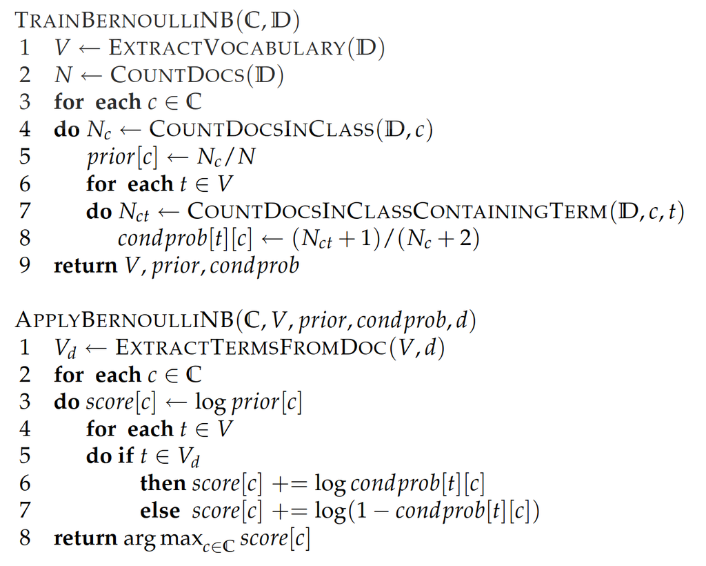

*Image 1*

The notations are as follows:  
$C$ – Set of all Classes (labels)  
$D$ – Set of all Documents (training dataset)

The training algorithm is roughly divided into 2 parts:  
$prior\lbrack c\rbrack$ – probability of the class $c$ or $P(c)$  
$cond\ prob\lbrack t\rbrack\lbrack c\rbrack$ – probability of a term *t* given class $c$ or $P(t\ |\ c)$

And in the testing algorithm it calculates and returns

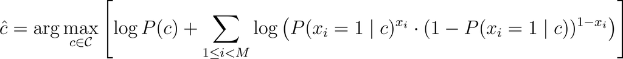

**Let's look at how this equation came about.**

The underlying formula used in naive bayes model to classify is

Where $c$ is the class and $d$ is a document, applying

[figure not shown]

the bayes rule we get,

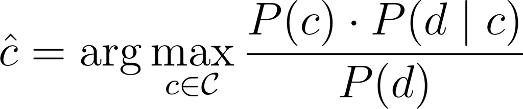

We do not care about the denominator as it remains same when calculating across each class, hence the equation further simplifies to,

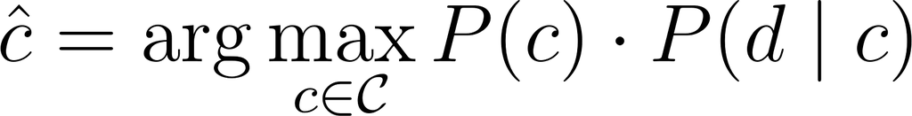

The calculation of $P(c)$ is done in the same way across all different variations in NB as

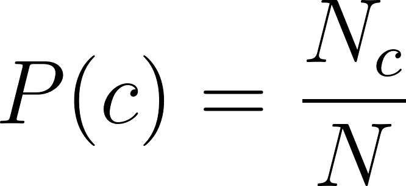

The main difference in each model comes from how we calculate $P(d\ |\ c)$, in the bernoulli model, we represent d as

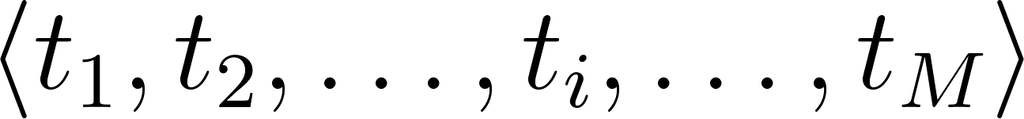

which is a binary vector ($ti$ is either 0 or 1) of dimensionality M (the number of terms in vocabulary V) that indicate for each term (in V) whether it exists in d or not, hence

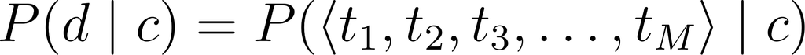

But we cannot directly use this as we have to compute $2^{M}.|C|$ different parameters, in order to tackle this we make the Naive Bayes conditional independence assumption, then the equation simplifies to

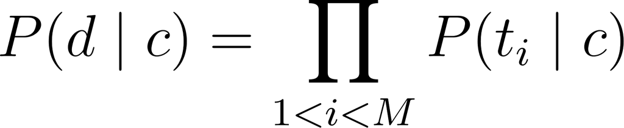

Now we introduce a random variable $Xi$ which takes the value 0 for absence and 1 for presence, then $P(Xi = 1\ |\ c)$ is the probability that in a document of class c the term $ti$ will occur – in any position and possibly multiple times.

[figure not shown]

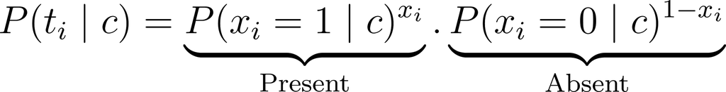

But,

Hence,

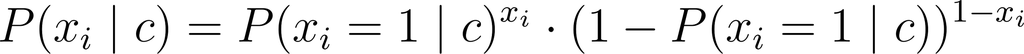

Now in order to calculate $P(Xi = 1\ |\ c)$ we do

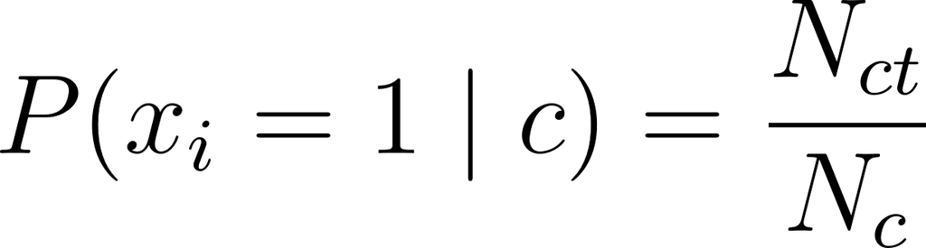

Where $N_{ct}$ is the number of documents in class $c$ containing term $t$ and $N_{c}$ is the number of documents in class $c$, But there may be cases where $N_{ct} = 0$, to prevent this we apply laplace (or add one) smoothing,

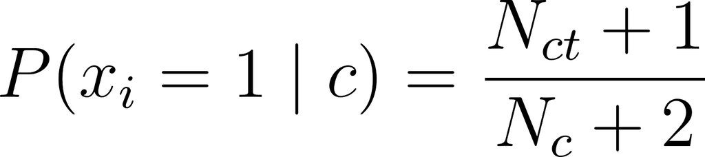

But why add 2 in the denominator, because

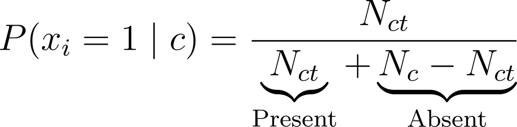

To smooth it uniformly we add 1 to all frequencies.

Now we have calculated all of the terms in $P(c/d)$, but still when we calculate the terms, we may run into floating point underflow, since probabilities can tend to 0, hence we apply log. Then we are

[figure not shown]

finally left with:

**Let's look at a small example applying the Bernoulli Model.**

| DocID | Words in Document | In c = China? |
| --- | --- | --- |
| 1 | Chinese, Beijing, Chinese | yes |
| 2 | Chinese, Chinese, Shanghai | yes |
| 3 | Chinese, Macao | yes |
| 4 | Tokyo, Japan, Chinese | no |
| 5 | Chinese, Chinese, Chinese, Tokyo, Japan | ? |
| 6 | Shanghai, Chinese, Japan | ? |

$P(Chinese|c) = \ (3 + 1)/(3 + 2) = 4/5$  
$P(Japan|c) = \ P(Tokyo|c) = \ (0 + 1)/(3 + 2) = 1/5$  
$P(Beijing|c) = \ P(Macao|c) = \ P(Shanghai|c) = (1 + 1)/(3 + 2) = 2/5$  
$P(Chinese|\underline{c}) = \ (1 + 1)/(1 + 2) = 2/3$  
$P(Japan|\underline{c}) = \ P(Tokyo|\underline{c}) = \ (1 + 1)/(1 + 2) = 2/3$  
$P(Beijing|\underline{c}) = \ P(Macao|\underline{c}) = \ P(Shanghai|\underline{c}) = (0 + 1)/(1 + 2) = 1/3$

Now the score for document 5 is -  
$P(c|d_{5})\ \propto \ P(c)\ .\ P(Chinese|c)\ .\ P(Tokyo|c)\ .\ P(Japan|c)\$  
$.\ \ (1 - P(Beijing|c))\ .\ (1 - P(Shanghai|c))\ .\ (1 - P(Macao|c))$  
$= 3/4\ .\ 4/5\ .\ 1/5\ .\ 1/5\ .\ (1 - 2/5)\ .\ (1 - 2/5)\ .\ (1 - 2/5)$  
$\approx 0.005$  
And, analogously,  
$P(\underline{c}|d_{5})\ \propto \ 1/4\ .\ 2/3\ .\ 2/3\ .\ 2/3\ .\ (1 - 1/3)\ .\ (1 - 1/3)\ .\ (1 - 1/3)$  
$\approx 0.022$  
Thus the classifier assigns the test document 5 to $not\ china$, as when looking at the binary occurrence and not at term frequency, Japan and Tokyo are indicators for not china  
($P(Japan|\underline{c}) > \ P(Japan|c)$) and the conditional probabilities of Chinese for $c$ and $\underline{c}$ are not different enough to affect the classification decision.

**Note**  
The Bernoulli Model is especially useful when the data set is small and the number of features is less (< dozen). NB’s main strength is its efficiency: Training and classification can be done with one pass over the data. Because it combines efficiency with good accuracy it is often used as a baseline in text classification research.

**References and further reading**  
C.D. Manning, P. Raghavan and H. Schuetze (2008) Introduction to Information Retrieval. Cambridge University Press. https://nlp.stanford.edu/IR-book/pdf/13bayes.pdf